# Project 2_CDA

Jaya MOTWANI(23990486), Kose SAJU(23680585)

2023-10-15

## Video Link : “https://youtu.be/0OtNxiDbkZU”

## Task Distribution :

Jaya Motwani (50%): Data Cleaning, Feature Selection, Clustering, Evaluation, Shiny App

Kose Saju (50%): Feature Selection, Single and Multivariate Classification, Evaluation, Shiny App

# Introduction

The data set provided analyzed here is “Global Youtube Statistics. csv” provided at CITS4009 Unit LMS Webpage.The provided data set appears to contain information related to popular YouTube channels, with several attributes and metrics associated with each channel.

The dataset seems to include details about various YouTube channels, such as their rankings, subscriber counts, video views, content categories, upload statistics, and earnings. Additionally, it contains information about the countries of origin for these channels, including abbreviations and certain demographic and economic indicators for those countries.

The dataset might be useful for conducting analyses related to YouTube channel popularity, content categories, and the financial aspects of YouTube channels. It could also serve as a valuable resource for exploring trends and relationships between these variables.

There is another dataset representing earnings against the social economic status of the country (e.g. normalised using GDP, or GDP per capita) which has been downloaded from Word Bank Webpage and is available at: https://data.worldbank.org/indicator/NY.GDP.PCAP.CD

Global Youtube Statistics dataset has 28 features ad 995 observations, where as World Bank GDP dataset has 67 features and 266 observations.

In this project, our aim is to decide a target variable out of the merged dataset from Youtube Statistics and World Bank GDP, which is suitable for a classification task and formulate it as a binary classification problem.

Another technique to be used is Clustering, for discovering hidden patterns in the dataset and visualize the clustering results.

```r
library("knitr")
library("dplyr")
library("ggplot2")
library("gridExtra")
library("tidyverse")
library("reshape2")
library("Hmisc")
library("vtreat")
library("corrplot")
library('ROCR')
library("ROCit")
library("pander")
library("rpart")
library("rpart.plot")
library("caret")
library("class")
library("cluster")
library("factoextra")
library("cluster")
library("gridExtra")
library("fpc")
library("klaR")
library("devtools")
install_github("ramhiser/clusteval")
library("clusteval")
library("MASS")
library("clustMixType")
```

## Part 1 : Data Preparation

#### Finding mismatching Country names in both the data frames

Now we will calculate Aggregated GDP in World Bank data frame for all the years from 1960 up to 2022 and add this column at the end.

```r
start_column <- which(names(wrld_bnk) == "X1960")
end_column <- which(names(wrld_bnk) == "X2022")

wrld_bnk <- wrld_bnk %>%
  mutate(Aggregated_GDP = rowMeans(wrld_bnk[, start_column:end_column], na.rm = TRUE))

wrld_sub <- wrld_bnk[, c("Country", "Aggregated_GDP")]  #subset of original world bank data
```

Now we will merge the two data frames using Country as a common column and it is a left outer join so that all the observations from Global Youtube dataset are included.

Now we can see that there are 4 columns related to earnings in the merged_df, out of which we are choosing to only keep one column which represents an average of yearly earnings. We are just trying to keep columns relevant to our classification task and get rid of all the unnecessary columns/duplicated columns/ highly correlated columns.

We are also removing creation_date having year as “1970”, since Youtube came into existence in 2005 only, so this is a invalid date for a youtube channel, hence we are converting it to NA.

Then we are creating a new column channel_lifetime to represent the age of the channel in number of days from the creation date till 15 Oct 2023.

Thereafter we have only chosen relevant columns for our classification task and dropped all other irrelevant columns having unique values and duplicated information.

```r
# Calculating average yearly earning for each youtube channel

mergd_df <- mergd_df %>%
              mutate(avg_earnings = rowMeans(mergd_df[, c("lowest_yearly_earnings", "highest_yearly_earnings")]))

#Combining date, month and year columns into a single column "creation_date"
mergd_df <- mergd_df %>%mutate(creation_date = paste(created_date, created_month , created_year, sep = "/"))
                      mergd_df$creation_date <- as.Date(mergd_df$creation_date, "%d/%b/%Y")

# Removing invalid creation_date
mergd_df$creation_date[format(mergd_df$creation_date, "%Y") == "1970"] <- NA

# Calculating channel_lifetime
mergd_df$channel_lifetime <- julian(Sys.Date()) - julian(mergd_df$creation_date)

# Selecting relevant columns
myvars <- c("Country", "subscribers", "video.views", "uploads", "channel_type", "video_views_for_the_last_30_days", "subscribers_for_last_30_days", "Gross.tertiary.education.enrollment....", "Population", "Unemployment.rate", "Urban_population", "Aggregated_GDP", "avg_earnings", "channel_lifetime")

unclean_df <- mergd_df[myvars]
```

```r
# Removing an extreme outlier
outlier_value <- 86800000

# Filtering the dataset dropping specific outlier value and zero values
out_removed <- unclean_df %>%
  filter(avg_earnings != outlier_value, avg_earnings != 0)

mean_avg_earnings <- mean(out_removed$avg_earnings) # calculating mean for binary classification of target variable

mean_avg_earnings
```

```
## [1] 3996093
```

### Target variable for Classification task

So we have chosen avg_earning (yearly) as our target variable for the classification, and here we are converting it to binary classes, having values of ‘0s’ representing “low income” and values of ‘1s’ representing “high income” for a youtube channel, and this is being added in the data frame as a new column “earnings_level”. Initially, we have chosen mean for finding the split point based on some previous scientific experiments and studies, but then we realized that since this is an imbalanced dataset, choosing mean as split point would not be the correct way of deciding low and high earnings youtube channel. So we have done some research on it and we found that an average youtube content creater makes around $100,000 per year, provided they hit the benchmark of one million subscribers and views. So considering that we have decided the split point between low and high earnings to be $100,000.

```r
# Creating target variable "earnings_level"
unclean_df$earnings_level <- ifelse((unclean_df$avg_earnings) > 100000, 1, 0)
```

```r
# Some housekeeping

rm(mergd_df, new, org, wrld_bnk, wrld_sub, u_tube)
```

### Handling “nan” and “NaN”

So we have heaps of “nan” and “NaN” in our data frame in channel_type and Country columns, therfore we areconverting them to “Unknowns” as a new category.

```r
# treating for nan characters

clean_data <- function(unclean_df) {
  clean_df <- unclean_df %>%
    mutate(
      across(where(is.numeric), ~ ifelse(is.nan(.), NA, .)),
      across(where(is.character), ~ ifelse(. %in% c("NaN", "nan"), NA, .)),
      channel_type = ifelse(is.na(channel_type), "Unknown", channel_type),
      Country = ifelse(is.na(Country), "Unknown", Country)
    )
  return(clean_df)
}

nan_treated <- clean_data(unclean_df)
```

### Handling Zeros

So we have 3 columns with multiple number of zeros, such as “video.views”,“uploads”, “avg_earnings”. So here we are just calculating the number of zeros in each of these variables.

```r
# Checking for number of zero values

count_zeros <- function(newdata) {
  zero_count <- sapply(newdata, function(x) sum(x == 0, na.rm = TRUE))

  return(zero_count)
}

zero_vars <- c("video.views","uploads", "avg_earnings")
print(count_zeros(nan_treated[,zero_vars]))
```

```
##  video.views      uploads avg_earnings
##            8           43           79
```

### Transforming Zeros

Now we are transforming zeros to ones to avoid having -Inf values while we transform our variables on logrithmic scalelater on.

```r
# Converting zeros to ones

rem_zero <- function(data, zero_vars) {
  treated_data <- data %>%
    mutate_at(vars(all_of(zero_vars)), ~ ifelse(. <= 0, . + 1, .))

  return(treated_data)
}
zero_treated <- rem_zero(nan_treated, zero_vars)
print(count_zeros(rem_zero(nan_treated, zero_vars)))
```

```
##                                 Country                             subscribers
##                                       0                                       0
##                             video.views                                 uploads
##                                       0                                       0
##                            channel_type        video_views_for_the_last_30_days
##                                       0                                       0
##            subscribers_for_last_30_days Gross.tertiary.education.enrollment....
##                                       0                                       0
##                              Population                       Unemployment.rate
##                                       0                                       0
##                        Urban_population                          Aggregated_GDP
##                                       0                                       0
##                            avg_earnings                        channel_lifetime
##                                       0                                       0
##                          earnings_level
##                                     202
```

```r
summary(zero_treated)
```

```
##    Country           subscribers         video.views           uploads
##  Length:995         Min.   : 12300000   Min.   :1.000e+00   Min.   :     1.0
##  Class :character   1st Qu.: 14500000   1st Qu.:4.288e+09   1st Qu.:   194.5
##  Mode  :character   Median : 17700000   Median :7.761e+09   Median :   729.0
##                     Mean   : 22982412   Mean   :1.104e+10   Mean   :  9187.2
##                     3rd Qu.: 24600000   3rd Qu.:1.355e+10   3rd Qu.:  2667.5
##                     Max.   :245000000   Max.   :2.280e+11   Max.   :301308.0
##
##  channel_type       video_views_for_the_last_30_days
##  Length:995         Min.   :1.000e+00
##  Class :character   1st Qu.:2.014e+07
##  Mode  :character   Median :6.408e+07
##                     Mean   :1.756e+08
##                     3rd Qu.:1.688e+08
##                     Max.   :6.589e+09
##                     NA's   :56
##  subscribers_for_last_30_days Gross.tertiary.education.enrollment....
##  Min.   :      1              Min.   :  7.60
##  1st Qu.: 100000              1st Qu.: 36.30
##  Median : 200000              Median : 68.00
##  Mean   : 349079              Mean   : 63.63
##  3rd Qu.: 400000              3rd Qu.: 88.20
##  Max.   :8000000              Max.   :113.10
##  NA's   :337                  NA's   :123
##    Population        Unemployment.rate Urban_population    Aggregated_GDP
##  Min.   :2.025e+05   Min.   : 0.750    Min.   :    35588   Min.   :  300.1
##  1st Qu.:8.336e+07   1st Qu.: 5.270    1st Qu.: 55908316   1st Qu.: 1397.6
##  Median :3.282e+08   Median : 9.365    Median :270663028   Median :13904.8
##  Mean   :4.304e+08   Mean   : 9.279    Mean   :224214982   Mean   :14738.3
##  3rd Qu.:3.282e+08   3rd Qu.:14.700    3rd Qu.:270663028   3rd Qu.:28194.1
##  Max.   :1.398e+09   Max.   :14.720    Max.   :842933962   Max.   :44243.9
##  NA's   :123         NA's   :123       NA's   :123         NA's   :122
##   avg_earnings      channel_lifetime earnings_level
##  Min.   :       0   Min.   : 484     Min.   :0.000
##  1st Qu.:  277200   1st Qu.:2696     1st Qu.:1.000
##  Median : 1379750   Median :3792     Median :1.000
##  Mean   : 3762036   Mean   :3887     Mean   :0.797
##  3rd Qu.: 3877550   3rd Qu.:5147     3rd Qu.:1.000
##  Max.   :86800000   Max.   :6698     Max.   :1.000
##                     NA's   :6
```

### Log Transformation of skewed variables

So as we can observe that many variables like “subscribers”, “video.views”, “uploads”, “video_views_for_the_last_30_days”, “subscribers_for_last_30_days” and “Population” are heavily skewed and might affect the classification task, so we are performing log transformation to align them with a normal scale.

```r
# Log transformation of skewed variables

log_transform <- function(data, variables) {

  for (var in variables) {
    data[[var]] <- log(data[[var]])
  }

  return(data)
}

skewed_vars <- c("subscribers", "video.views", "uploads", "video_views_for_the_last_30_days", "subscribers_for_last_30_days", "Population")

skew_treated <- log_transform(zero_treated, skewed_vars)
```

```r
# Number of rows with more than 10% NAs

sum(rowSums(is.na(skew_treated)) / ncol(skew_treated) > 0.1)
```

```
## [1] 137
```

```r
# Function to check and filter rows according to number of NAs present

rowchecker <- function(data, threshold) {
  # Calculate the NA percentage for each row
  na_percentages <- rowSums(is.na(data)) / ncol(data) * 100

  # Keep rows where NA percentage is less than or equal to the threshold
  filtered_data <- data[na_percentages <= threshold, ]

  return(filtered_data)
}
```

```r
# number of response as 1

sum(skew_treated$earnings_level)
```

```
## [1] 793
```

```r
# sum of NAs in each column

count_missing <- function(df) {
  sapply(df, FUN = function(col) sum(is.na(col)) )
}
```

Now we are checking total count of NAs across all the variables in the data frame.

```r
count_missing(skew_treated)
```

```
##                                 Country                             subscribers
##                                       0                                       0
##                             video.views                                 uploads
##                                       0                                       0
##                            channel_type        video_views_for_the_last_30_days
##                                       0                                      56
##            subscribers_for_last_30_days Gross.tertiary.education.enrollment....
##                                     337                                     123
##                              Population                       Unemployment.rate
##                                     123                                     123
##                        Urban_population                          Aggregated_GDP
##                                     123                                     122
##                            avg_earnings                        channel_lifetime
##                                       0                                       6
##                          earnings_level
##                                       0
```

### Using V-treat for handling missing values

```r
# vtreating everything except categorical columns such as "Country", "channel_type", "earnings_level"

v_treater <- function(df, excluded_vars) {
  col_list <- setdiff(colnames(df), c("Country", "channel_type", "earnings_level"))
  treatment_plan <- design_missingness_treatment(df, varlist = col_list)
  training_prepared <- prepare(treatment_plan, df)
  count_missing(training_prepared)
  return(training_prepared)
}

excluded_vars <- c("Country", "channel_type", "earnings_level")
vtreat_prepared  <- v_treater(skew_treated, excluded_vars)
vtreat_clustering <- v_treater (zero_treated, excluded_vars)
count_missing(vtreat_prepared)
```

```
##                                   Country
##                                         0
##                              channel_type
##                                         0
##                            earnings_level
##                                         0
##                               subscribers
##                                         0
##                               video_views
##                                         0
##                                   uploads
##                                         0
##          video_views_for_the_last_30_days
##                                         0
##    video_views_for_the_last_30_days_isBAD
##                                         0
##              subscribers_for_last_30_days
##                                         0
##        subscribers_for_last_30_days_isBAD
##                                         0
##      Gross_tertiary_education_enrollment_
##                                         0
## Gross_tertiary_education_enrollment_isBAD
##                                         0
##                                Population
##                                         0
##                          Population_isBAD
##                                         0
##                         Unemployment_rate
##                                         0
##                   Unemployment_rate_isBAD
##                                         0
##                          Urban_population
##                                         0
##                    Urban_population_isBAD
##                                         0
##                            Aggregated_GDP
##                                         0
##                      Aggregated_GDP_isBAD
##                                         0
##                              avg_earnings
##                                         0
##                          channel_lifetime
##                                         0
##                    channel_lifetime_isBAD
##                                         0
```

As we can see after the V-treat transformation all the missing values have been imputed across all the columns. we have selected suitable subsets of variables for classification as well as clustering task to keep the model simple, easy to execute and interpret.The variables which are dropped are either missing value indicators or redundant.

## Part 2(A) :Feature Selection Techniques

It is very important to apply some feature selection techniques to get rid of duplicated variables before modelling. So the first technique used is Correlation Coefficient Matrix to drop the variables based on correlation with other variables.

## 2.A.1. Correlation Coefficient Matrix [Feature Selection #1]

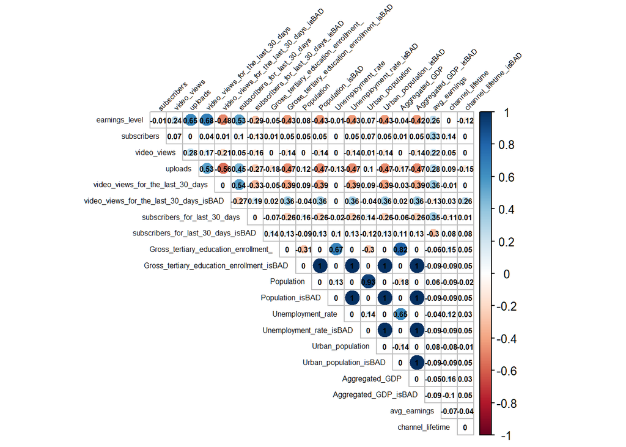

```r
num_df <- vtreat_prepared[sapply(vtreat_prepared,is.numeric)]

cor_matrix <- cor(num_df, use = "pairwise.complete.obs")
corrplot(
  cor_matrix,
  method = "circle",
  type = "upper",  # Display only the upper triangle of the matrix
  tl.col = "black",  # Label color
  tl.srt = 45,       # Label rotation angle
  addCoef.col = "black",  # Coefficient color
  tl.cex = 0.5,
  number.cex = 0.5,
  diag = FALSE       # Exclude diagonal elements
)
```

So here we can see that”Gross_tertiary_education_enrollment_“and”Unemployment_rate” have high degree of correlation with Aggregated_GDP and “Urban_population” has high correlation coefficient with “Population”. Hence we are dropping these three variables and all other missingness indicater variables. Also creation_date is similiar to channel_lifetime so we have dropped it as well.And since we already converted avg_earnings to earnings_levels as our target binary variable, we dont require avg_earnings as well.

### Selecting subset of variables based on Correlation Matrix

```r
# Preparing data frame for classification task
training_prepared <- vtreat_prepared[,!names(vtreat_prepared) %in% c("Gross_tertiary_education_enrollment_", "Unemployment_rate","Urban_population", "subscribers_for_last_30_days_isBAD", "video_views_for_the_last_30_days_isBAD", "Population_isBAD", "Gross_tertiary_education_enrollment_isBAD", "Unemployment_rate_isBAD", "Urban_population_isBAD", "Aggregated_GDP_isBAD", "channel_lifetime_isBAD","avg_earnings", "video_views_isBAD", "GDP_mean_70s_isBAD",
"GDP_mean_10s_isBAD", "creation_date", "uploads_isBAD")]

# Preparing data frame for clustering task
vtreat_clustering2 <- vtreat_clustering[,names(vtreat_clustering) %in% c("Country", "channel_type", "subscribers","subscribers_for_last_30_days","video_views","video_views_for_the_last_30_days","uploads", "Population", "Aggregated_GDP", "channel_lifetime", "avg_earnings", "earnings_level")]

vtreat_clustering2$earnings_level <- ifelse((vtreat_clustering2$earnings_level) == 0, "Low", "High")

write.csv(vtreat_clustering2, file = "main_df.csv", row.names = FALSE) #exporting for clustering
```

```r
# House keeping

rm(myvars, outlier_value, skewed_vars, zero_vars, num_df, excluded_vars)
```

Setting the target variable and assigning the majority class as success outcome.

```r
# Set the success outcome as the majority class and outcome variable

pos <- "1"
outcome <- "earnings_level"
```

### Splitting the data

We start by splitting the cleaned data into Train, Test and Calibration set. A seed value is set to make the results reproducible. The Train-Test split is set at a reasonable 90/10. Another 10 percent split is done from the train set to obtain the calibration set which could used for hyper parameter tuning before testing.

```r
# setting seed and splitting train, test and calibration
set.seed(729375)

train_splitter <- function(data, split_val){
  data$index <- runif(dim(data)[1])

  tr_data_all <- subset(data, index <= split_val)[,-which(names(data) == "index")]
  te_data_df <- subset(data , index > split_val)[,-which(names(data) == "index")]

  # names of columns that are categorical type and numerical type
  vars <- setdiff(colnames(tr_data_all), c("earnings_level", "index"))
  catVars <- vars[sapply(tr_data_all[, vars], class) %in%c('factor', 'character')]
  numericVars <- vars[sapply(tr_data_all[, vars], class) %in%c('numeric', 'integer')]

  # split tr_data_all into a training set and a validation (or calibration) set
  cal_index <- rbinom(n=dim(tr_data_all)[1], size=1, prob=0.1)>0
  df_cal <- subset(tr_data_all, cal_index)
  train_df <- subset(tr_data_all, !cal_index)

  data_frames_list <- list(train_df, te_data_df, df_cal, catVars, numericVars)

  return(data_frames_list)
}

result <- train_splitter(training_prepared, 0.9)

train_df <- result[[1]]
test_df <- result[[2]]
cal_df <- result[[3]]
catVars <- result[[4]]
numericVars <- result[[5]]
```

# Single Variate Modelling

Train single variable models from all the categorical variables and caluclate predictions

```r
mkPredC <- function(outCol, varCol, appCol) {
  pPos <- sum(outCol == pos) / length(outCol)
  naTab <- table(as.factor(outCol[is.na(varCol)]))
  pPosWna <- (naTab/sum(naTab))[pos]
  vTab <- table(as.factor(outCol), varCol)
  pPosWv <- (vTab[pos, ] + 1.0e-3*pPos) / (colSums(vTab) + 1.0e-3)
  pred <- pPosWv[appCol]
  pred[is.na(appCol)] <- pPosWna
  pred[is.na(pred)] <- pPos
  pred
}
```

```r
for(v in catVars) {
  pi <- paste('pred', v, sep='')
  train_df[,pi] <- mkPredC(train_df[,outcome], train_df[,v], train_df[,v])
  cal_df[,pi] <- mkPredC(train_df[,outcome], train_df[,v], cal_df[,v])
  test_df[,pi] <- mkPredC(train_df[,outcome], train_df[,v], test_df[,v])
}
```

Using the pred value for Country and channel type as respective numerical encoding. This would allow us to plug in the categorical variables into models and functions that can only handle numerical values. Creating in a new data frame with suffix _encod with pred values replacing the original categorical variables.

```r
cat_encod <- rbind(train_df, cal_df, test_df)
cat_encod <- cat_encod[, !names(cat_encod) %in% c("Country", "channel_type")]
```

```r
calcAUC <- function(predcol,outcol) {
  perf <- performance(prediction(predcol,outcol==pos),'auc')
  as.numeric(perf@y.values)
}
```

Evaluating the AUC values for the categorical variables

```r
for(v in catVars) {
  pi <- paste('pred', v, sep='')
  aucTrain <- calcAUC(train_df[,pi], train_df[,outcome])
  if (aucTrain >= 0.55) {
    aucCal <- calcAUC(cal_df[,pi], cal_df[,outcome])
    print(sprintf(
        "%s: trainAUC: %4.3f; calibrationAUC: %4.3f",
          pi, aucTrain, aucCal))
    }
}
```

```
## [1] "predCountry: trainAUC: 0.790; calibrationAUC: 0.706"
## [1] "predchannel_type: trainAUC: 0.717; calibrationAUC: 0.587"
```

Evacuating the AUC values for the same in test data set

```r
# Initialize empty vectors to store results
Variables <- character(0)
AUC_Test <- numeric(0)

for (v in catVars) {
  pi <- paste('pred', v, sep='')
  aucTrain <- calcAUC(train_df[, pi], train_df[, outcome])

  if (aucTrain >= 0.55) {
    aucTest <- calcAUC(test_df[, pi], test_df[, outcome])

    # Append values to vectors
    Variables <- c(Variables, v)
    AUC_Test <- c(AUC_Test, round(aucTest, 3))
  }
}
```

The Country variable seems to be a strong predictive variable with a score of 0.7 in the calibration set

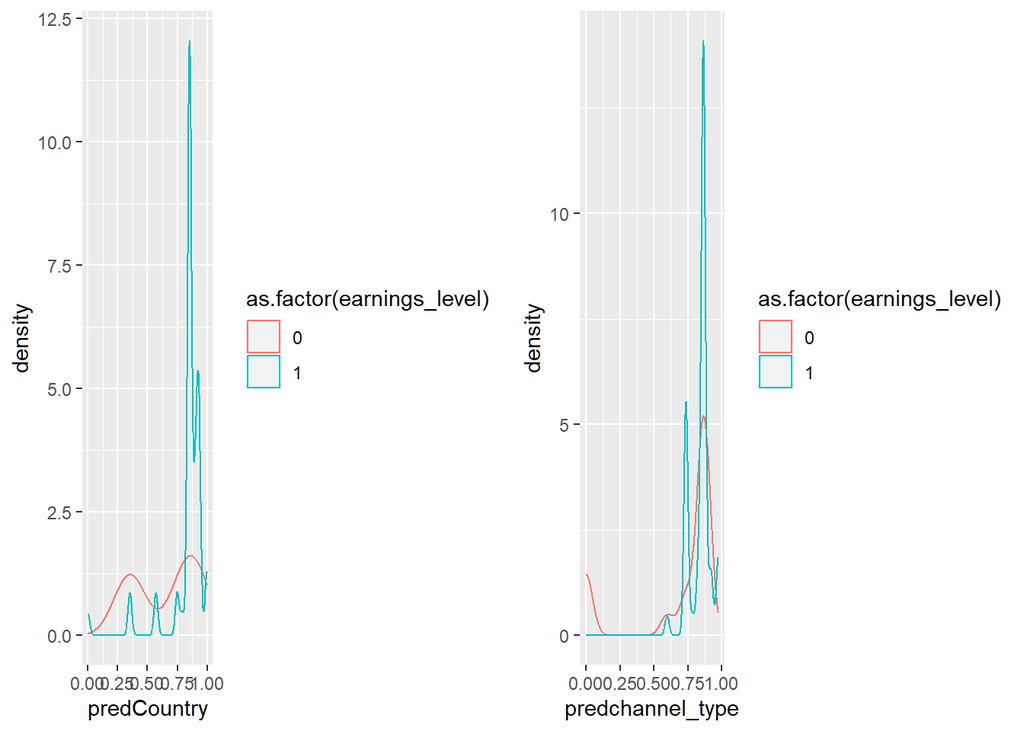

```r
# Double Density plots

fig1 <- ggplot(cal_df) + geom_density(aes(x=predCountry, color=as.factor(earnings_level)))
fig2 <- ggplot(cal_df) + geom_density(aes(x=predchannel_type, color=as.factor(earnings_level)))
grid.arrange(fig1, fig2, ncol=2)
```

We can see clear distillation for predicting 1s as outcome in Country’s double density plot. The unbalanced number of 1s in the original data set is therefore favorable for the variable.

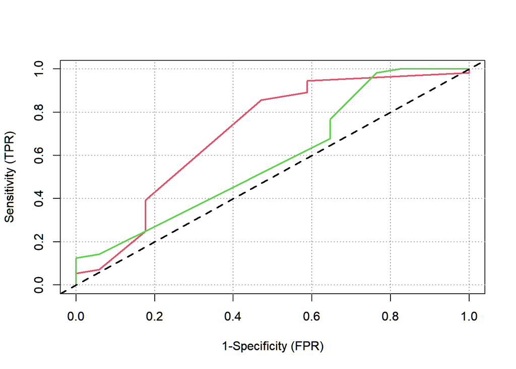

```r
# colour_id 1-7 are: black,red,green,blue,cyan,purple,gold
plot_roc <- function(predcol, outcol, colour_id=2, overlaid=F) {
  ROCit_obj <- rocit(score=predcol, class=outcol==pos)
  par(new=overlaid)
  plot(ROCit_obj, col = c(colour_id, 1),
  legend = FALSE, YIndex = FALSE, values = FALSE)
}

plot_roc(cal_df$predCountry, cal_df[,outcome]) #red
plot_roc(cal_df$predchannel_type, cal_df[,outcome], colour_id=3, overlaid=T) # green
```

Unsurprisingly the ROC curve for predCountry performs better than predchannel_type.

### Numerical single variables

To make use of the mKpredC function for numerical single variate analysis we bin all the numerical variables into classes of 10 and calculate predictions and AUC values.

```r
# Binning numerical vars and calling mkPredC

mkPredN <- function(outCol, varCol, appCol) {
  # compute the cuts
  cuts <- unique(
  quantile(varCol, probs=seq(0, 1, 0.1), na.rm=T))
  # discretize the numerical columns
  varC <- cut(varCol,cuts)
  appC <- cut(appCol,cuts)
  mkPredC(outCol,varC,appC)
}
```

```r
for(v in numericVars) {
  pi <- paste('pred', v, sep='')
  train_df[,pi] <- mkPredN(train_df[,outcome], train_df[,v], train_df[,v])
  cal_df[,pi] <- mkPredN(train_df[,outcome], train_df[,v], cal_df[,v])
  test_df[,pi] <- mkPredN(train_df[,outcome], train_df[,v], test_df[,v])
  aucTrain <- calcAUC(train_df[,pi], train_df[,outcome])
  if(aucTrain >= 0.55) {
    aucCal <- calcAUC(cal_df[,pi], cal_df[,outcome])
    print(sprintf("%s: trainAUC: %4.3f; calibrationAUC: %4.3f",
    pi, aucTrain, aucCal))
  }
}
```

```
## [1] "predsubscribers: trainAUC: 0.586; calibrationAUC: 0.457"
## [1] "predvideo_views: trainAUC: 0.619; calibrationAUC: 0.510"
## [1] "preduploads: trainAUC: 0.866; calibrationAUC: 0.808"
## [1] "predvideo_views_for_the_last_30_days: trainAUC: 0.942; calibrationAUC: 0.851"
## [1] "predsubscribers_for_last_30_days: trainAUC: 0.827; calibrationAUC: 0.776"
## [1] "predPopulation: trainAUC: 0.732; calibrationAUC: 0.694"
## [1] "predAggregated_GDP: trainAUC: 0.707; calibrationAUC: 0.701"
## [1] "predchannel_lifetime: trainAUC: 0.660; calibrationAUC: 0.497"
```

```r
for(v in numericVars) {
  pi <- paste('pred', v, sep='')
  train_df[,pi] <- mkPredN(train_df[,outcome], train_df[,v], train_df[,v])
  cal_df[,pi] <- mkPredN(train_df[,outcome], train_df[,v], cal_df[,v])
  test_df[,pi] <- mkPredN(train_df[,outcome], train_df[,v], test_df[,v])
  aucTrain <- calcAUC(train_df[,pi], train_df[,outcome])
  if(aucTrain >= 0.55) {
    aucTest <- calcAUC(test_df[,pi], test_df[,outcome])

    Variables <- c(Variables, v)
    AUC_Test <- c(AUC_Test, round(aucTest, 3))
  }
}

test_AUC_df <- cbind(Variables, AUC_Test)
test_AUC_df <- as.data.frame(test_AUC_df)
test_AUC_df <- test_AUC_df[order(test_AUC_df$AUC_Test, decreasing = TRUE), ]
test_AUC_df
```

```
##                           Variables AUC_Test
## 6  video_views_for_the_last_30_days    0.961
## 5                           uploads    0.845
## 7      subscribers_for_last_30_days    0.824
## 8                        Population    0.703
## 9                    Aggregated_GDP    0.701
## 2                      channel_type    0.638
## 4                       video_views    0.633
## 1                           Country    0.625
## 3                       subscribers    0.479
## 10                 channel_lifetime    0.429
```

We find a few real strong predictors in the numerical variable list. The “predvideo_views_for_the_last_30_days” scores a calibration AUC of 0.851

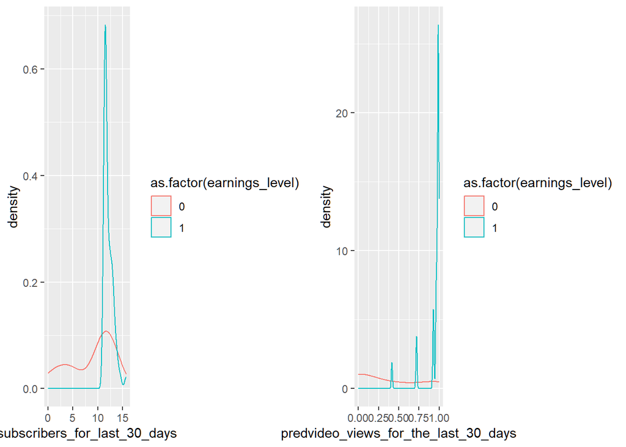

```r
fig1 <- ggplot(cal_df) + geom_density(aes(x=subscribers_for_last_30_days, color=as.factor(earnings_level)))
fig2 <- ggplot(cal_df) + geom_density(aes(x=predvideo_views_for_the_last_30_days, color=as.factor(earnings_level)))
grid.arrange(fig1, fig2, ncol=2)
```

We can clearly see a huge leap in outcome of 1s corresponding to very high values of predvideo_views_for_the_last_30_days.

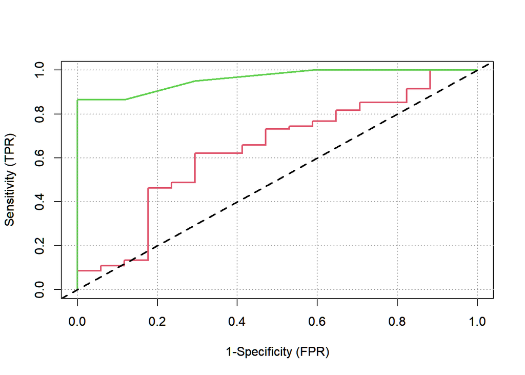

```r
plot_roc(test_df$video_views, test_df[,outcome]) #red
plot_roc(test_df$predvideo_views_for_the_last_30_days, test_df[,outcome], colour_id=3, overlaid=T) #green
```

The ROC curve for predvideo_views_for_the_last_30_days seems almost perfect.

```r
# House keeping

rm(aucCal, aucTrain, fig1, fig2, pi, result, v)
```

### Null Model and Evaluation Metrics

```r
(Npos <- sum(train_df[,outcome] == 0))
```

```
## [1] 168
```

```r
pred.Null <- Npos / nrow(train_df)
cat("Proportion of outcome == 1 in dTrain:", pred.Null)
```

```
## Proportion of outcome == 1 in dTrain: 0.2041312
```

```r
TP <- 0; TN <- sum(cal_df[,outcome] == 0); # using threshold 0.5
FP <- 0; FN <- sum(cal_df[,outcome] == 1); # using threshold 0.5
cat("nrow(dCal):", nrow(cal_df), "TP:", TP, "TN:", TN, "FP:", FP, "FN:", FN)
```

```
## nrow(dCal): 73 TP: 0 TN: 17 FP: 0 FN: 56
```

```r
(accuracy <- (TP + TN) / nrow(cal_df))
```

```
## [1] 0.2328767
```

```r
(precision <- TP/(TP + FP))
```

```
## [1] NaN
```

```r
(recall <- TP/(TP + FN))
```

```
## [1] 0
```

```r
pred.Null <- rep(pred.Null, nrow(cal_df))
(AUC <- calcAUC(pred.Null, cal_df[,outcome]))
```

```
## [1] 0.5
```

## 2.A.2 Log Likelihood and Deviance [Feature Selection #2]

```r
# Define a function to compute log likelihood so that we can reuse it.
logLikelihood <- function(ytrue, ypred, epsilon=1e-6) {
  sum(ifelse(ytrue==pos, log(ypred+epsilon), log(1-ypred-epsilon)), na.rm=T)
}
# Compute the likelihood of the Null model on the calibration
# set (for the KDD dataset from previous lecture)
logNull <- logLikelihood(cal_df[,outcome], sum(cal_df[,outcome]==pos)/nrow(cal_df))

cat(logNull)
```

```
## -39.61922
```

We have our Null model log likelihood to compare to all other multivariate models.

### Categorical feature selection with Deviance

```r
deviance_sel <- c()

minDrop <- 0 # may need to adjust this number
for (v in catVars) {
  pi <- paste('pred', v, sep='')
  devDrop <- 2*(logLikelihood(cal_df[,outcome], cal_df[,pi]) - logNull)
  if (devDrop <= minDrop) {
    print(sprintf("%s, deviance reduction: %g", pi, devDrop))
    deviance_sel <- c(deviance_sel, pi)
  }
}
```

```
## [1] "predCountry, deviance reduction: -3.45296"
```

```r
minDrop <- 0 # may need to adjust this number
for (v in numericVars) {
  pi <- paste('pred', v, sep='')
  devDrop <- 2*(logLikelihood(cal_df[,outcome], cal_df[,pi]) - logNull)
  if (devDrop <= minDrop) {
    print(sprintf("%s, deviance reduction: %g", pi, devDrop))
    deviance_sel <- c(deviance_sel, pi)
  }
}
```

```
## [1] "predsubscribers, deviance reduction: -2.51467"
## [1] "predvideo_views, deviance reduction: -2.67529"
## [1] "predvideo_views_for_the_last_30_days, deviance reduction: -1.82811"
## [1] "predsubscribers_for_last_30_days, deviance reduction: -21.8094"
## [1] "predchannel_lifetime, deviance reduction: -3.49885"
```

Evaluvating the deviance score of all variables

```r
# Initialize empty vectors to store results
Variables <- character(0)
Deviance_Test <- numeric(0)

minDrop <- 100 # may need to adjust this number
for (v in catVars) {
  pi <- paste('pred', v, sep='')
  devDrop <- 2*(logLikelihood(test_df[,outcome], test_df[,pi]) - logNull)
  if (devDrop <= minDrop) {

    Variables <- c(Variables, v)
    Deviance_Test <- c(Deviance_Test, round(devDrop, 3))
  }
}

for (v in numericVars) {
  pi <- paste('pred', v, sep='')
  devDrop <- 2*(logLikelihood(test_df[,outcome], test_df[,pi]) - logNull)
  if (devDrop <= minDrop) {
    Variables <- c(Variables, v)
    Deviance_Test <- c(Deviance_Test, round(devDrop, 3))

  }
}

test_dev_df <- cbind(Variables, Deviance_Test)
test_dev_df <- as.data.frame(test_dev_df)
test_dev_df <- test_dev_df[order(abs(as.numeric(test_dev_df$Deviance_Test))), ]
test_dev_df
```

```
##                           Variables Deviance_Test
## 8                        Population         0.058
## 2                      channel_type        -7.078
## 9                    Aggregated_GDP        -7.978
## 4                       video_views        -8.359
## 5                           uploads         11.49
## 7      subscribers_for_last_30_days        13.765
## 3                       subscribers       -14.736
## 10                 channel_lifetime       -19.418
## 1                           Country       -34.809
## 6  video_views_for_the_last_30_days        44.725
```

We have a subset of 6 variables selected using their deviance scores.

Creating a new data frame with suffix _dev to be used in multivariate modelling.

```r
train_dev <- train_df[, c(deviance_sel, outcome)]
test_dev <- test_df[, c(deviance_sel, outcome)]
cal_dev <- cal_df[, c(deviance_sel, outcome)]
```

```r
# House keeping

rm(accuracy, AUC, devDrop, FN, FP, logNull, minDrop, Npos, precision,
   pred.Null, recall, TN, TP, v)
```

## 2.A.3. Information Gain [Feature Selection #3] (Jette, 2019)

```r
entropy <- function(target) {
  freq <- table(target)/length(target)
  # vectorize
  vec <- as.data.frame(freq)[,2]
  #dropping 0 to avoid NaN resulting from log2
  vec<-vec[vec>0]
  #compute entropy
  -sum(vec * log2(vec))
}

entropy(training_prepared$earnings_level)   # just for example
```

```
## [1] 0.7279174
```

### Information Gain for Numerical Variables Only

```r
IG_numeric<-function(data, feature, target, bins=4) {
  #Strip out rows where feature is NA
  data<-data[!is.na(data[,feature]),]
  #compute entropy for the parent
  e0<-entropy(data[,target])

  data$cat<-cut(data[,feature], breaks=bins, labels=c(1:bins))

  #use dplyr to compute e and p for each value of the feature
  dd_data <- data %>% group_by(cat) %>% summarise(e=entropy(get(target)),
                 n=length(get(target)),
                 min=min(get(feature)),
                 max=max(get(feature))
                 )

  #calculate p for each value of feature
  dd_data$p<-dd_data$n/nrow(data)
  #compute IG
  IG<-e0-sum(dd_data$p*dd_data$e)

  return(IG)
}
```

```r
cal_IG <- function(features, dataset) {
  n <- length(features)
  col_name <- vector("character", n)
  ig <- vector("numeric", n)
  for (i in 1:n) {
    col_name[i] <- names(features)[i]
    ig[i] <- IG_numeric(dataset, names(features)[i], "earnings_level", bins = 4)                                                               }
  ig_df <- cbind(col_name, "Information Gain" = round(ig, 5))
  ig_df <- as.data.frame(ig_df)
  df_sorted <- ig_df[order(ig_df[, 2], decreasing = TRUE), ]
  return(df_sorted)
}
```

```r
features <- training_prepared[,!(names(training_prepared) %in% c("Country", "channel_type", "earnings_level"))]
df_IG <- cal_IG(features, training_prepared)
df_IG
```

```
##                           col_name Information Gain
## 4 video_views_for_the_last_30_days          0.39679
## 3                          uploads          0.32086
## 5     subscribers_for_last_30_days          0.20667
## 7                   Aggregated_GDP           0.0705
## 2                      video_views          0.02859
## 8                 channel_lifetime          0.01081
## 6                       Population          0.00385
## 1                      subscribers          0.00043
```

```r
features <- cat_encod[,!(names(cat_encod) %in% c("earnings_level"))]
ig_org_sel_df <- cal_IG(features, cat_encod)
ig_selc_features <- ig_org_sel_df$col_name[1:5]
```

```r
enc_result <- train_splitter(cat_encod, 0.9)

train_enc <- enc_result[[1]]
test_enc <- enc_result[[2]]
cal_enc <- enc_result[[3]]
```

So since here we have calculated information gain for numeric variables only, so it has been applied to all 8 numeric variables in our data frame and we can see that the most important feature for predicting target variable is “video_views_for_the last_30_days” and the least important one is “subscribers”. And we have chosen a subset of top five variables out of this list sorted in decreasing order of IG value.

### Information Gain for Catergorical Variables Only

```r
#returns IG for categorical variables.
IG_cat<-function(data,feature,target){
  #Strip out rows where feature is NA
  data<-data[!is.na(data[,feature]),]
  #use dplyr to compute e and p for each value of the feature
  dd_data <- data %>% group_by_at(feature) %>% summarise(e=entropy(get(target)),
                 n=length(get(target))
                 )

  #compute entropy for the parent
  e0<-entropy(data[,target])
  #calculate p for each value of feature
  dd_data$p<-dd_data$n/nrow(data)
  #compute IG
  IG<-e0-sum(dd_data$p*dd_data$e)

  return(IG)
}
```

```r
IG_Country <- IG_cat(training_prepared,"Country", "earnings_level")
IG_Channel_type <- IG_cat(training_prepared,"channel_type", "earnings_level")
IG_Country
```

```
## [1] 0.1547194
```

```r
IG_Channel_type
```

```
## [1] 0.1109335
```

As we can make out clearly that both our categorical variables “Country” and “channel_type” are important for predicting the target variable, so we would be holding onto both of them in our final subset.

```r
# House keeping

rm(enc_result, IG_Channel_type, IG_Country, ig_org_sel_df)
```

# Part 2(B) Multi-variate Classification Models

Defining functions that will calculate accuracy, precision, recall and F1 for the models we create.

```r
performanceMeasures <- function(ytrue, ypred,
                                model.name = "model", threshold=0.5) {
  # compute the normalised deviance
  dev.norm <- -2 * logLikelihood(ytrue, ypred)/length(ypred)
  # compute the confusion matrix
  cmat <- table(actual = ytrue, predicted = ypred >= threshold)
  accuracy <- sum(diag(cmat)) / sum(cmat)
  precision <- cmat[2, 2] / sum(cmat[, 2])
  recall <- cmat[2, 2] / sum(cmat[2, ])
  f1 <- 2 * precision * recall / (precision + recall)

  data.frame(model = model.name, precision = precision,recall = recall,
             f1 = f1, dev.norm = dev.norm)
}
```

```r
panderOpt <- function(){
  # setting up Pander Options
  panderOptions("plain.ascii", TRUE)
  panderOptions("keep.trailing.zeros", TRUE)
  panderOptions("table.style", "simple")
}
```

```r
pretty_perf_table <- function(model, xtrain, ytrain, xtest, ytest, m = 0, threshold = 0.5, title = "Performance Table") {
  # Option setting for Pander
  panderOpt()
  perf_justify <- "lrrrr"

  # Create the title line
  cat(paste0("## ", title, "\n"))

  if (m == 1) {
    # comparing performance on training vs. test
    trainperf_df <- performanceMeasures(
      xtrain, ytrain, model.name = "training", threshold = threshold)
    testperf_df <- performanceMeasures(
      xtest, ytest, model.name = "test", threshold = threshold)
    # combine the two performance data frames using rbind()
    perftable <- rbind(trainperf_df, testperf_df)
    pandoc.table(perftable, justify = perf_justify)
  } else {
    # call the predict() function to do the predictions
    pred_train <- predict(model, newdata = xtrain)
    pred_test <- predict(model, newdata = xtest)
    # comparing performance on training vs. test
    trainperf_df <- performanceMeasures(
      ytrain, pred_train, model.name = "training", threshold = threshold)
    testperf_df <- performanceMeasures(
      ytest, pred_test, model.name = "test", threshold = threshold)
    # combine the two performance data frames using rbind()
    perftable <- rbind(trainperf_df, testperf_df)
    pandoc.table(perftable, justify = perf_justify)
  }
}
```

#2.B.1 Decison Tree Model [Multi-variate Classification Model #1]

We are trying out three different Decision Tree model, one with all the numerical variables as features, second with features selected with deviance score and third being the features selected using Information Gain.

```r
fV_all <- paste(outcome,' ~ ', paste(c(numericVars), collapse=' + '), sep='')
fV_dev <- paste(outcome,' ~ ', paste(c(deviance_sel), collapse=' + '), sep='')
fV_ig <- paste(outcome,' ~ ', paste(c(ig_selc_features), collapse=' + '), sep='')

dt_model_all <- rpart(fV_all, data = train_df[,c(numericVars, outcome)])
dt_model_dev <- rpart(fV_dev, data = train_dev)
dt_model_ig <- rpart(fV_ig, data = train_enc)
```

```r
all_dt_auc <- data.frame(model = "all_dt_auc",
             train = calcAUC(predict(dt_model_all, newdata=train_df[,numericVars]), train_df[,outcome]),
             test = calcAUC(predict(dt_model_all, newdata=test_df[,numericVars]), test_df[,outcome]),
             cal = calcAUC(predict(dt_model_all, newdata=cal_df[,numericVars]), cal_df[,outcome]))

dev_dt_auc <- data.frame(model = "dev_dt_auc",
             train = calcAUC(predict(dt_model_dev, newdata=train_dev), train_dev[,outcome]),
             test = calcAUC(predict(dt_model_dev, newdata=test_dev), test_dev[,outcome]),
             cal = calcAUC(predict(dt_model_dev, newdata=cal_dev), cal_dev[,outcome]))

ig_dt_auc <- data.frame(model = "ig_dt_auc",
             train = calcAUC(predict(dt_model_ig, newdata=train_enc), train_enc[,outcome]),
             test = calcAUC(predict(dt_model_ig, newdata=test_enc), test_enc[,outcome]),
             cal = calcAUC(predict(dt_model_ig, newdata=cal_enc), cal_enc[,outcome]))

perftable <- rbind(all_dt_auc, dev_dt_auc, ig_dt_auc)
cat("AUC for all three feature subsets using decision tree model")
```

```
## AUC for all three feature subsets using decision tree model
```

```r
pandoc.table(perftable, justify = "lrrr")
```

```
##
## ---------------------------------------
## model           train     test      cal
## ------------ -------- -------- --------
## all_dt_auc     0.9554        1   0.8824
##
## dev_dt_auc     0.9417   0.9727   0.8624
##
## ig_dt_auc      0.9548   0.9444   0.9444
## ---------------------------------------
```

```r
pretty_perf_table(dt_model_all, train_df[numericVars], train_df[,outcome]==pos,
                  test_df[numericVars], test_df[,outcome]==pos, title = "DT Model - all features")
```

```
## ## DT Model - all features
##
##
## model        precision   recall       f1   dev.norm
## ---------- ----------- -------- -------- ----------
## training        0.9776        1   0.9887      6.186
## test            1.0000        1   1.0000      6.294
```

```r
pretty_perf_table(dt_model_dev, train_dev[deviance_sel], train_dev[,outcome]==pos,
                  test_dev[deviance_sel], test_dev[,outcome]==pos, title = "DT Model - dev features")
```

```
## ## DT Model - dev features
##
##
## model        precision   recall       f1   dev.norm
## ---------- ----------- -------- -------- ----------
## training        0.9261   0.9954   0.9595      5.646
## test            0.9318   1.0000   0.9647      5.771
```

```r
pretty_perf_table(dt_model_ig, train_enc[ig_selc_features], train_enc[,outcome]==pos,
                  test_enc[ig_selc_features], test_enc[,outcome]==pos, title = "DT Model - IG features")
```

```
## ## DT Model - IG features
##
##
## model        precision   recall       f1   dev.norm
## ---------- ----------- -------- -------- ----------
## training        0.9773        1   0.9885      6.163
## test            0.9762        1   0.9880      6.360
```

## Selection of Evaluation Metric

Looking at all the performance metrics we have obtained for the model, emphasis is given to the F1 score over all others. Since we have an imbalanced data set we need to strike a balance between type 1 and type 2 errors as the intrinsic imbalance of the data set itself can skew the balance in a direction. This coupled with the fact that neither False Positives nor False Negatives are a higher implications to our decision (ie both are equally undesirable in this case) we go for the F1 score which provides us the balanced trade off between precision and recall.

Using that metric we can once again see that the model with all the variables selected performs better. This is followed by IG selected feature model and finally the deviance feature set.

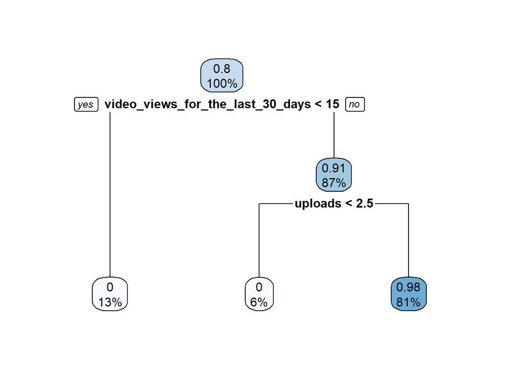

```r
par(cex=1)
rpart.plot(dt_model_all)
```

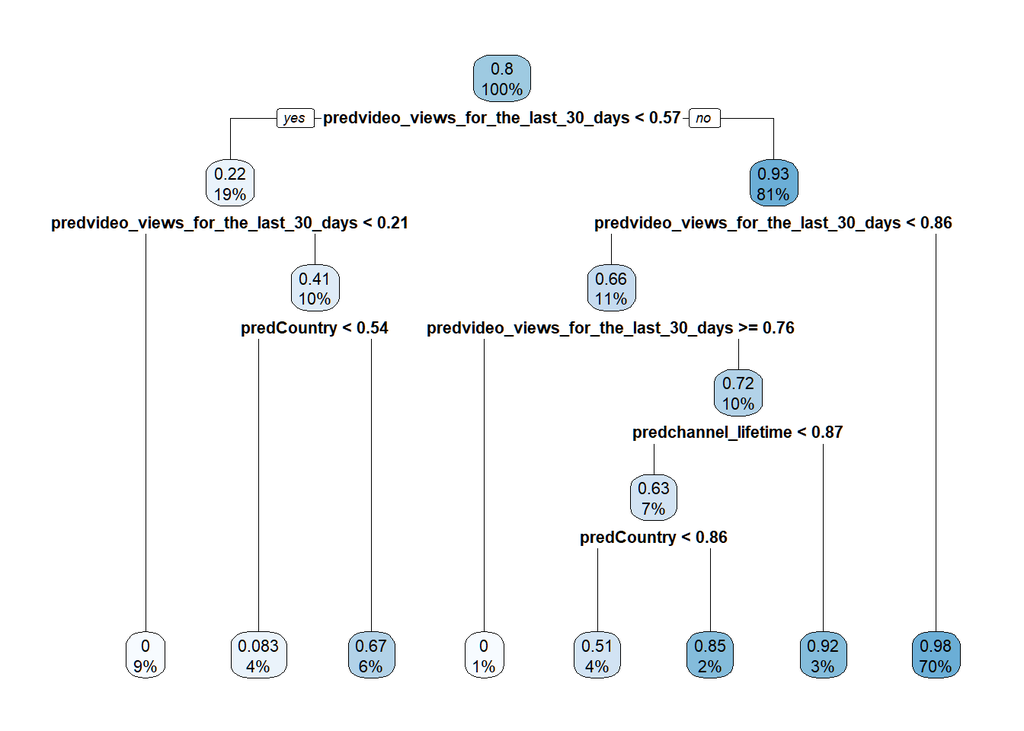

```r
par(cex=1)
rpart.plot(dt_model_dev)
```

Unlike our last model the feature set filled the pred value of each variable seems to grow the decision tree in a more random pattern. We could therefore infer that there might be a lesser correlation between the numerical value of the variable and the earnings level we are trying to predict. This might also explain the slight lower performance this model showcased in the models above.

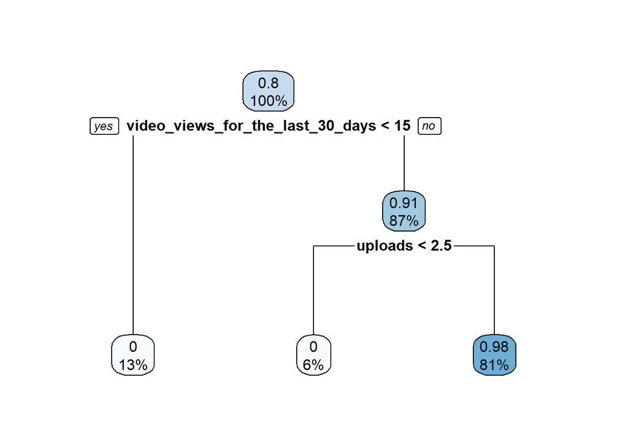

```r
par(cex=1)
rpart.plot(dt_model_ig)
```

The IG selected features also allows for a more structured growth of the tree as we saw with the model that was trained on all the variables.

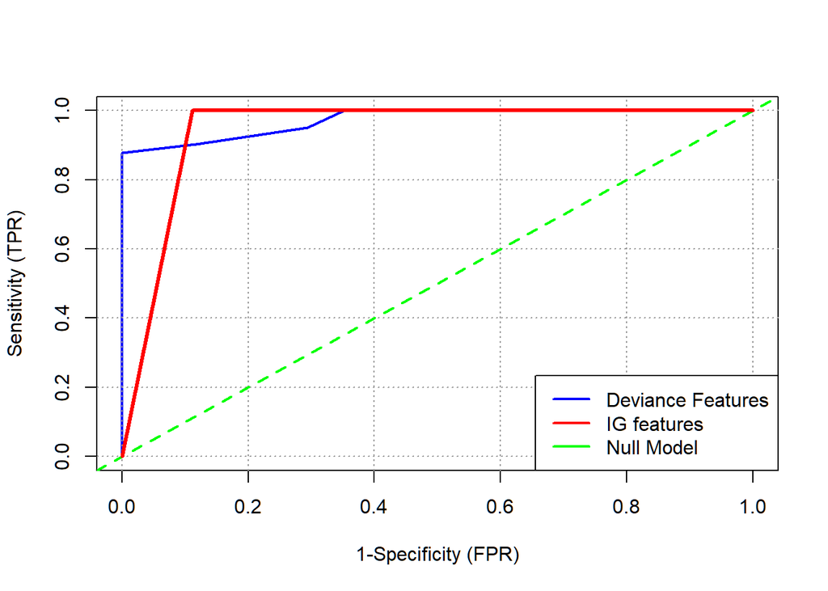

```r
plot_roc <- function(predcol1, outcol1, predcol2, outcol2, a, b){
  roc_1 <- rocit(score=predcol1, class=outcol1==pos)
  roc_2 <- rocit(score=predcol2, class=outcol2==pos)
  plot(roc_1, col = c("blue","green"), lwd = 3,
  legend = FALSE,YIndex = FALSE, values = TRUE, asp=1)
  lines(roc_2$TPR ~ roc_2$FPR, lwd = 3,
  col = c("red","green"), asp=1)
  legend("bottomright", col = c("blue","red", "green"),
  c(a, b, "Null Model"), lwd = 2)
}
pred_dev_roc <- predict(dt_model_dev, newdata=test_dev)
pred_ig_roc <- predict(dt_model_ig, newdata=test_enc)

plot_roc(pred_dev_roc, test_dev[[outcome]],
pred_ig_roc, test_enc[[outcome]], "Deviance Features", "IG features")
```

From the ROC charts we can see that the model with the deviance feature performs better than model with IG features.

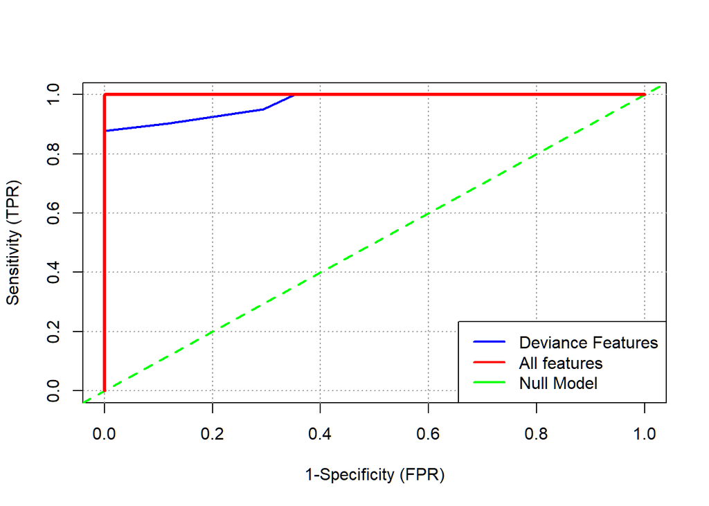

```r
pred_dev_roc <- predict(dt_model_dev, newdata=test_dev)
pred_all_roc <- predict(dt_model_all, newdata=test_df[numericVars])

plot_roc(pred_dev_roc, test_dev[[outcome]],
pred_all_roc, test_df[[outcome]], "Deviance Features", "All features")
```

The test data set with all features fits perfectly despite being a good outcome is a bit too good to be true. A better understanding of how the model actually fits to the data set can only be obtained via a cross validation method.

#2.B.2 k-Nearest Neighbours [Multi-variate Classification Model #2]

Next we implement a k-Nearest Neighbor model on the IG and deviance feature sets

```r
knnAUC <- function(train_data, cal_data, test_data,
                   train_labels, cal_labels, test_labels,
                   k, features, m = 0) {

  knnCl <- train_labels == pos

  knnPredict <- function(df) {
    knnDecision <- knn(train_data, df, knnCl,
                       k = k, prob = TRUE)
    ifelse(knnDecision == TRUE,
           attributes(knnDecision)$prob,
           1 - attributes(knnDecision)$prob)
  }

  cal_data$knnProb <- knnPredict(cal_data[, features])
  test_data$knnProb <- knnPredict(test_data[, features])
  train_data$knnProb <- knnPredict(train_data[, features])

  cal_data$earnings_level <- cal_labels
  test_data$earnings_level <- test_labels
  train_data$earnings_level <- train_labels

  auc_cal <- calcAUC(cal_data$knnProb, cal_labels)
  auc_test <- calcAUC(test_data$knnProb, test_labels)

  if(m == 1){
    return(list(K = k, AUC_cal = auc_cal, AUC_test = auc_test))
  }else{
  return(list(cal_data ,test_data, train_data))
  }
}
```

```r
k_values <- 1:30
results <- list()

# Perform KNN and AUC calculation for different K values
for (k in k_values) {
  result <- knnAUC(train_df[, deviance_sel], cal_dev,
                   test_dev, train_dev[, outcome],
                   cal_dev[, outcome], test_dev[, outcome],
                   k, deviance_sel, 1)
  results[[as.character(k)]] <- unlist(result)
}

  # Convert results to a data frame
  results_df <- do.call(rbind, results)
  results_df <- as.data.frame(results_df)

  # Find the K value with the highest AUC on the validation set
  best_k_dev <- results_df[which.max(results_df$AUC_cal), "K"]

  cat("The best K value on deviance features is:", best_k_dev, "\n")
```

```
## The best K value on deviance features is: 4
```

```r
  cat("AUC on the test set for the best K:",
      results_df[which.max(results_df$AUC_cal), "AUC_test"])
```

```
## AUC on the test set for the best K: 0.9770445
```

```r
k_values <- 1:30
results <- list()

# Perform KNN and AUC calculation for different K values
for (k in k_values) {
  result <- knnAUC(train_enc[, ig_selc_features], cal_enc,
                   test_enc, train_enc[, outcome],
                   cal_enc[, outcome], test_enc[, outcome],
                   k, ig_selc_features, 1)
  results[[as.character(k)]] <- unlist(result)
}

  # Convert results to a data frame
  results_df <- do.call(rbind, results)
  results_df <- as.data.frame(results_df)

  # Find the K value with the highest AUC on the validation set
  best_k_ig <- results_df[which.max(results_df$AUC_cal), "K"]

  cat("The best K value on IG features is:", best_k_ig, "\n")
```

```
## The best K value on IG features is: 7
```

```r
  cat("AUC on the test set for the best K:",
      results_df[which.max(results_df$AUC_cal), "AUC_test"])
```

```
## AUC on the test set for the best K: 0.9627371
```

Using AUC as the metric found the best K value for the kNN model for both IG and deviance feature sets by validating against the calibration set. The values for both models being higher than 3 and lower than 10 suggest low risk of over fitting and under fitting respectively. We will have to now conduct predictions on the test data set before we can draw conclusions. Let us fit both models to their optimum value of k to derive models for testing.

```r
result <- knnAUC(train_df[, deviance_sel], cal_dev,
                 test_dev, train_dev[, outcome],
                 cal_dev[, outcome], test_dev[, outcome],
                 best_k_dev, deviance_sel)

knn_cal_dev <- result[[1]]
knn_test_dev <- result[[2]]
knn_train_dev <- result[[3]]
```

```r
result <- knnAUC(train_enc[, ig_selc_features], cal_enc,
                 test_enc, train_enc[, outcome],
                 cal_enc[, outcome], test_enc[, outcome],
                 best_k_ig, ig_selc_features)

knn_cal_ig <- result[[1]]
knn_test_ig <- result[[2]]
knn_train_ig <- result[[3]]
```

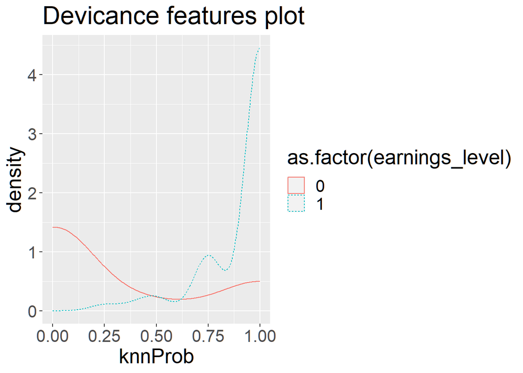

```r
ggplot(data=knn_cal_dev) + geom_density(aes(x=knnProb,
                                        color=as.factor(earnings_level),
                                        linetype=as.factor(earnings_level))) +
    theme(text=element_text(size=20)) + ggtitle("Devicance features plot")
```

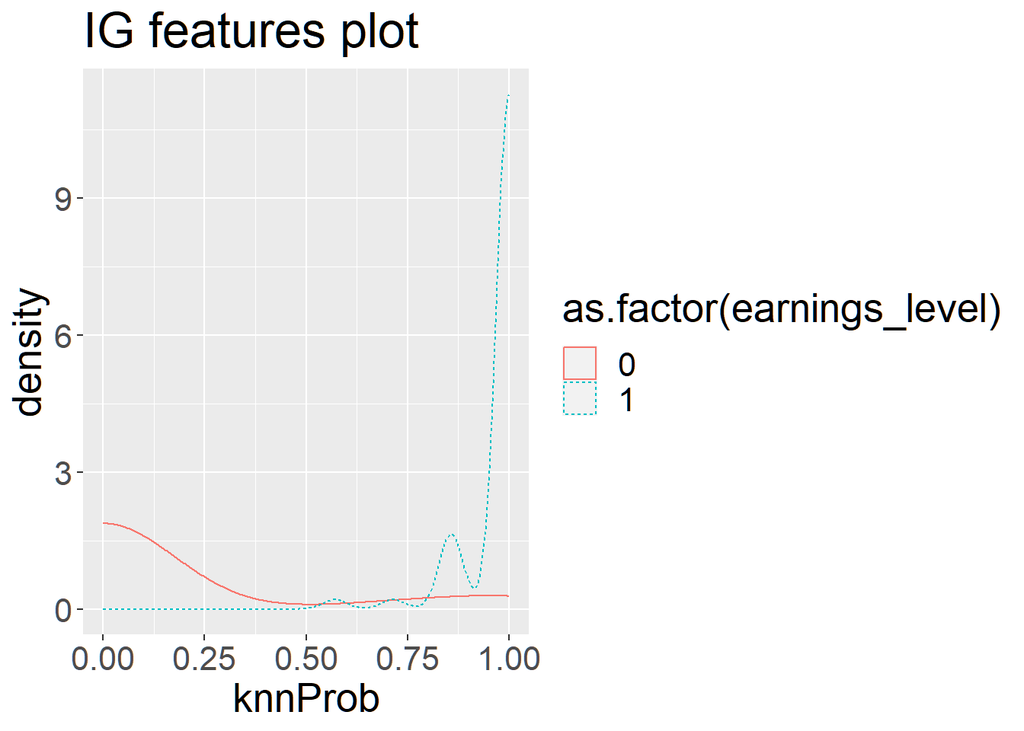

```r
ggplot(data=knn_cal_ig) + geom_density(aes(x=knnProb,
                                        color=as.factor(earnings_level),
                                        linetype=as.factor(earnings_level))) +
    theme(text=element_text(size=20)) + ggtitle("IG features plot")
```

```r
plotROC <- function(ypred, ytrue, titleString="ROC plot") {
  perf <- performance(prediction(ypred, ytrue), 'tpr', 'fpr')
  pf <- data.frame(FalsePositiveRate=perf@x.values[[1]],
  TruePositiveRate=perf@y.values[[1]])
  ggplot() + geom_line(data=pf, aes(x=FalsePositiveRate, y=TruePositiveRate),
  colour="red") +
  labs(title=titleString) +
  geom_line(aes(x=c(0,1), y=c(0,1))) +
  theme(text=element_text(size=24))
}
```

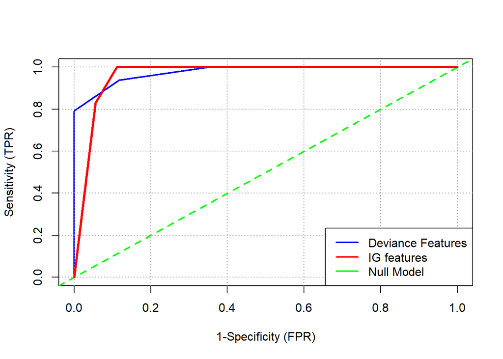

```r
plot_roc(knn_test_dev$knnProb, knn_test_dev[[outcome]],
knn_test_ig$knnProb, knn_test_ig[[outcome]], "Deviance Features", "IG features")
```

### Dev feature model without threshold

```r
pretty_perf_table(NULL, knn_train_dev[,outcome] == 1, knn_train_dev$knnProb,
                  knn_test_dev[,outcome] ==1, knn_test_dev$knnProb, 1, title = "kNN Model - dev features")
```

```
## ## kNN Model - dev features
##
##
## model        precision   recall       f1   dev.norm
## ---------- ----------- -------- -------- ----------
## training        0.9354   0.9954   0.9645     0.4096
## test            0.9318   1.0000   0.9647     0.5622
```

### IG feature model with threshold

```r
pretty_perf_table(NULL, knn_train_ig[,outcome] == 1, knn_train_ig$knnProb,
                  knn_test_ig[,outcome] ==1, knn_test_ig$knnProb, 1, 0.8, title = "kNN Model - IG features with threshold")
```

```
## ## kNN Model - IG features with threshold
##
##
## model        precision   recall       f1   dev.norm
## ---------- ----------- -------- -------- ----------
## training        0.9785   0.9876   0.9831     0.4772
## test            0.9762   1.0000   0.9880     0.5869
```

### IG feature model without threshold

```r
pretty_perf_table(NULL, knn_train_ig[,outcome] == 1, knn_train_ig$knnProb,
                  knn_test_ig[,outcome] ==1, knn_test_ig$knnProb, 1, title = "kNN Model - IG features")
```

```
## ## kNN Model - IG features
##
##
## model        precision   recall       f1   dev.norm
## ---------- ----------- -------- -------- ----------
## training        0.9743   0.9985   0.9862     0.4772
## test            0.9762   1.0000   0.9880     0.5869
```

The IG feature model predicted the same with the artificial threshold when compared to prediction made at 0.5 threshold. Another look at the double density plot shows how the small values of 0s and 1s on both side of the threshold eventually adds up to negate any benefit we thought we might have keeping the threshold very close to the start of the peak of 1s density. Incidentally we can see that the precision improved marginally on the case with threshold indicating a drop in false positive which is exactly what we expect.

# Classification : Results Discussion

```r
pretty_perf_table(NULL, knn_train_ig[,outcome] == 1, knn_train_ig$knnProb,
                  knn_test_ig[,outcome] ==1, knn_test_ig$knnProb, 1, title = "kNN Model - IG features")
```

```
## ## kNN Model - IG features
##
##
## model        precision   recall       f1   dev.norm
## ---------- ----------- -------- -------- ----------
## training        0.9743   0.9985   0.9862     0.4772
## test            0.9762   1.0000   0.9880     0.5869
```

```r
pretty_perf_table(dt_model_ig, train_enc[ig_selc_features], train_enc[,outcome]==pos,
                  test_enc[ig_selc_features], test_enc[,outcome]==pos, title = "DT Model - IG features")
```

```
## ## DT Model - IG features
##
##
## model        precision   recall       f1   dev.norm
## ---------- ----------- -------- -------- ----------
## training        0.9773        1   0.9885      6.163
## test            0.9762        1   0.9880      6.360
```

Looking at all four models we have created two decision trees and two kNN models our major findings are as follows:

1. In both case the models trained on the IG feature set faired better than the deviance data set counterparts.
2. The decision tree results are more interpretable and explainable giving us more trust in the decisions.
3. All multivariate models constructed performed way better than the best single variate model and the Null model

Comparing the two models both on the IG feature set, the difference in F1 performance is marginal, but the deviance score is found to be better for the kNN model. But given the metrics and the fact the DT model is more interpretable we conclude that the DT model is better than the kNN model for the given data set.

# Part 3 : Kmeans Clustering

## Selecting clustering tecnique: Why Kmeans?

K-means and hierarchical clustering are both popular unsupervised machine learning techniques used for clustering.Although each approach has its own advantages and is suitable for different types of data and scenarios, Kmeans is based on Euclidean distance which works well for numerical variables. Since our data set is a mix of numerical and categorical variables, and we have converted categorical to numerical during classification task, so we can easily run it through kmeans method. Kmeans is preferred over Hierarchical because its computationally faster, its easy to implement and understand, and has clear boundaries between clusters.

It classifies objects in multiple groups (i.e., clusters), such that objects within the same cluster are as similar as possible (i.e., high intra-class similarity), whereas objects from different clusters are as dissimilar as possible (i.e., low inter-class similarity). In k-means clustering, each cluster is represented by its center (i.e, centroid) which corresponds to the mean of points assigned to the cluster.The basic idea behind k-means clustering consists of defining clusters so that the total intra-cluster variation (known as total within-cluster variation) is minimized.Each observation is assigned to a given cluster such that the sum of squares (SS) distance of the observation to their assigned cluster centers is minimized.The total within-cluster sum of square measures the compactness (i.e goodness) of the clustering and we want it to be as small as possible.

## Selecting features for clustering.

### Feature Combination 1

So we have selected a total of eight numerical features from the output obtained using Information Gain and Log Likelihood feature selection methods as shown in Part 2. These are “subscribers”,“video_views”,“uploads”, “video_views_for_the_last_30_days”, “subscribers_for_last_30_days”, “Population”, “Aggregated_GDP”, “channel_lifetime”, “avg_earnings”. And since this technique works with numerical data only, so we can represent our two categorical variables “Country” with “Aggregated_GDP” and “channel_type” with “avg_earnings”. Hence we have added avg_earnings to our eight features and it makes a total of nine features which we are using in implementation of kmeans algorithm. As far as data preparation for clustering is concerned, we have used scale () function to bring all the variables centered around mean as “0” and standard deviation as “1”.

### Feature Combination #2

For experimenting purposes only we have selected ten features, all numerical values obtained consistently as an output from mkPredC and mkPredN functions,(i.e. derived from the target variable) i.e.”predCountry”, “predchannel_type”, “predsubscribers”, “predvideo_views”, “preduploads”,“predvideo_views_for_the_last_30_days”, “predsubscribers_for_last_30_days”, “predPopulation”, “predAggregated_GDP”, “predchannel_lifetime”.No scaling is required for them since they are all representing proportions between 0 and 1.

```r
vars_to_drop <- c("Country", "channel_type","earnings_level")      #for feature combination #1

vars_to_select <- c("predCountry", "predchannel_type", "predsubscribers", "predvideo_views", "preduploads", "predvideo_views_for_the_last_30_days", "predsubscribers_for_last_30_days", "predPopulation", "predAggregated_GDP", "predchannel_lifetime")     #for feature combination #2

clust_df <- training_prepared[, !(names(training_prepared) %in% vars_to_drop)]

combined_df_pred <- rbind(train_df,test_df, cal_df)
clust_df_pred <- combined_df_pred[, (names(combined_df_pred) %in% vars_to_select)]

clust_df$avg_earnings <- vtreat_prepared$avg_earnings

clust_df$ID <- seq.int(nrow(clust_df))
clust_df1 <- subset(clust_df, select = -ID)

clust_df_pred$ID <- seq.int(nrow(clust_df_pred))
clust_df_pred1 <- subset(clust_df_pred, select = -ID)


# Scaling the selected columns
scaled_df <- scale(clust_df1)

# Checking the structure of 'scaled_df'
attributes(scaled_df)$`scaled:center`
```

```
##                      subscribers                      video_views
##                     1.681722e+01                     2.251922e+01
##                          uploads video_views_for_the_last_30_days
##                     6.327762e+00                     1.674778e+01
##     subscribers_for_last_30_days                       Population
##                     1.144384e+01                     1.922357e+01
##                   Aggregated_GDP                 channel_lifetime
##                     1.473834e+04                     3.887203e+03
##                     avg_earnings
##                     3.762036e+06
```

```r
attributes(scaled_df)$`scaled:scale`
```

```
##                      subscribers                      video_views
##                     4.496495e-01                     2.304783e+00
##                          uploads video_views_for_the_last_30_days
##                     2.715832e+00                     4.321442e+00
##     subscribers_for_last_30_days                       Population
##                     2.474871e+00                     1.209234e+00
##                   Aggregated_GDP                 channel_lifetime
##                     1.148151e+04                     1.567968e+03
##                     avg_earnings
##                     7.329103e+06
```

## Initial number of clusters (arbitrarily chosen) = 5

```r
kbest.p <- 5
# running kmeans with 4 clusters, 100 random starts, and 100 maximum iterations per run.
kmClusters <- kmeans(scaled_df, kbest.p, nstart=100, iter.max=100)
kmClusters$size
```

```
## [1]  57   9  98 447 384
```

```r
kmClusters$centers
```

```
##   subscribers  video_views     uploads video_views_for_the_last_30_days
## 1  1.46022319  0.651223865  0.74978209                        0.9062260
## 2  1.89978711 -9.390941881 -2.24005925                       -1.0059650
## 3  0.11667583  0.046323050 -1.63013414                       -2.4545519
## 4 -0.07749079  0.093210678 -0.03371965                        0.2060651
## 5 -0.20085066  0.003109075  0.39648121                        0.2756089
##   subscribers_for_last_30_days Population Aggregated_GDP channel_lifetime
## 1                   0.97345662  0.2504303    -0.11495355      -0.24701294
## 2                   0.05552635  0.1063153     0.39065102       0.05393893
## 3                  -2.15330935 -0.3216106     0.07538663      -0.02661000
## 4                   0.13735779 -0.2110867     0.85100047       0.27684717
## 5                   0.24385057  0.2881308    -1.00194950      -0.28007452
##   avg_earnings
## 1    3.1911088
## 2   -0.5133009
## 3   -0.5132344
## 4   -0.1940704
## 5   -0.1047580
```

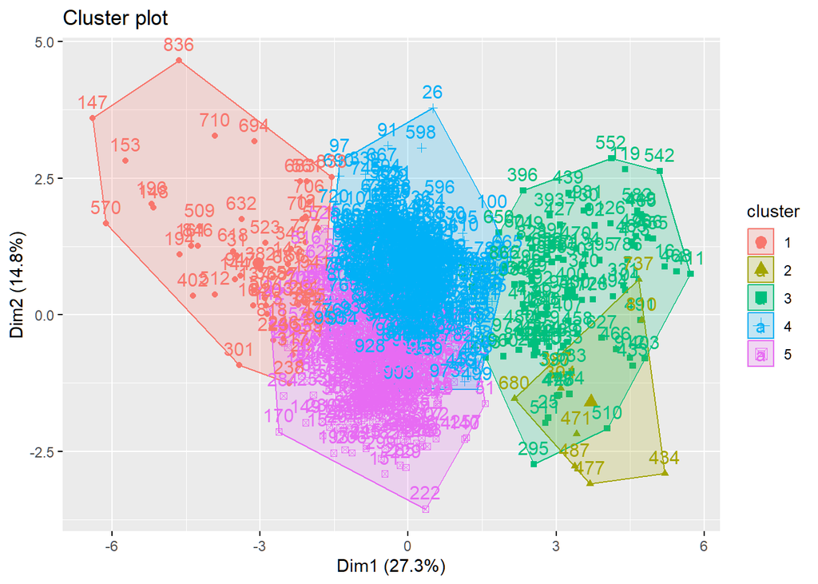

```r
fviz_cluster(kmClusters, data = scaled_df)
```

## Finding optimal number of clusters

So here we are computing k-means for different number of clusters to further compare their plots.

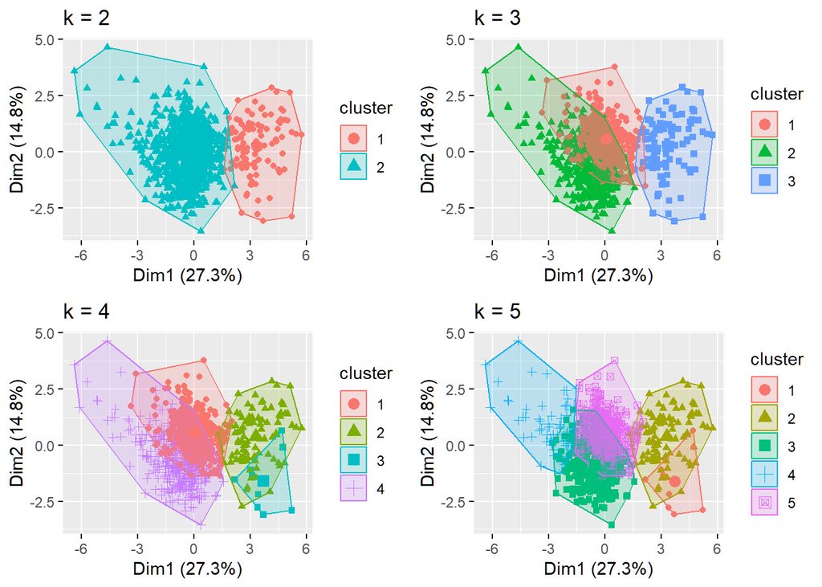

```r
k2 <- kmeans(scaled_df, centers = 2, nstart = 100, iter.max=100)
k3 <- kmeans(scaled_df, centers = 3, nstart = 100, iter.max=100)
k4 <- kmeans(scaled_df, centers = 4, nstart = 100, iter.max=100)
k5 <- kmeans(scaled_df, centers = 5, nstart = 100, iter.max=100)

# plots to compare
p2 <- fviz_cluster(k2, geom = "point", data = scaled_df) + ggtitle("k = 2")
p3 <- fviz_cluster(k3, geom = "point",  data = scaled_df) + ggtitle("k = 3")
p4 <- fviz_cluster(k4, geom = "point",  data = scaled_df) + ggtitle("k = 4")
p5 <- fviz_cluster(k5, geom = "point",  data = scaled_df) + ggtitle("k = 5")


grid.arrange(p2, p3, p4, p5, nrow = 2)
```

## Three techniques to find optimal number of clusters (Boehmke,2018)

So we have used CH (Calinski-Harabasz) index, Elbow method and Average Silhouette Width (ASW) method to find optimal number of clusters.

```r
set.seed(65496)

#CH_Index
kmClustering.ch <- kmeansruns(scaled_df, krange=1:10, criterion="ch")
kmClustering.ch$bestk
```

```
## [1] 2
```

```r
cat("K\tCH_Index\n")
```

```
## K    CH_Index
```

```r
for (i in 1:10) {
  cat(paste(i, "\t", kmClustering.ch$crit[i], "\n" ))
}
```

```
## 1     0
## 2     212.376307915408
## 3     194.17842338106
## 4     196.510940699739
## 5     209.718812006828
## 6     206.537067863236
## 7     205.90033801714
## 8     202.876989302925
## 9     201.076486232342
## 10    196.474909187365
```

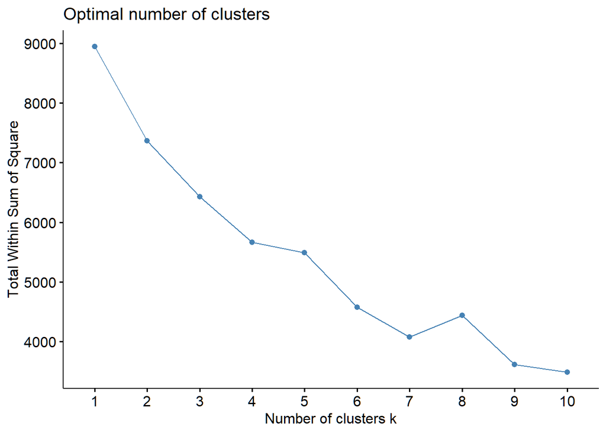

```r
#Elbow Method
fviz_nbclust(scaled_df, kmeans, method = "wss")
```

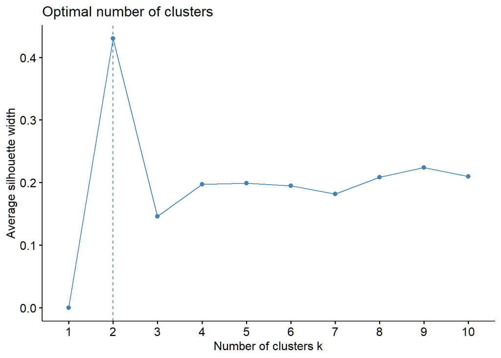

```r
#ASW Method
fviz_nbclust(scaled_df, kmeans, method = "silhouette")
```

#Interpretation of Output of three techniques :

So all three techniques suggest optimal number of clusters as 2. Let’s have a detailed look at cluster statistics for k=2.

```r
k2
```

```
## K-means clustering with 2 clusters of sizes 106, 889
##
## Cluster means:
##   subscribers video_views   uploads video_views_for_the_last_30_days
## 1  0.25408082 -0.70372045 -1.664720                       -2.3617165
## 2 -0.03029535  0.08390817  0.198493                        0.2815995
##   subscribers_for_last_30_days  Population Aggregated_GDP channel_lifetime
## 1                   -2.0036354 -0.29626787      0.1053792     -0.009900703
## 2                    0.2389037  0.03532553     -0.0125649      0.001180511
##   avg_earnings
## 1  -0.51323742
## 2   0.06119591
##
## Clustering vector:
##   1   2   3   4   5   6   7   8   9  10  11  12  13  14  15  16  17  18  19  20
```

[output cut: 108 more lines]

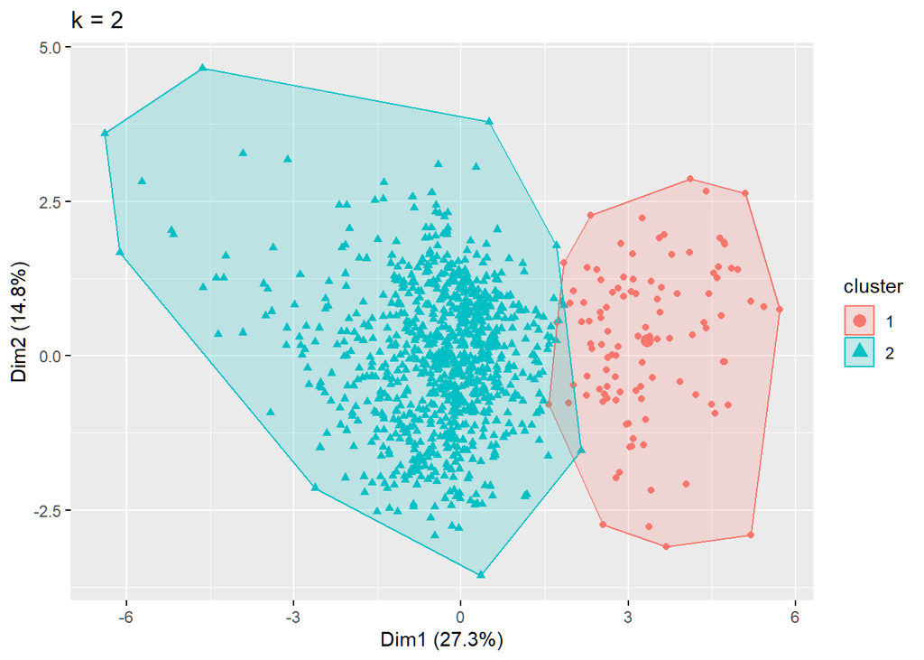

```r
p2
```

```r
k4
```

```
## K-means clustering with 4 clusters of sizes 474, 98, 9, 414
##
## Cluster means:
##   subscribers video_views     uploads video_views_for_the_last_30_days
## 1 -0.08016625  0.09320418 -0.03508509                        0.2115726
## 2  0.11667583  0.04632305 -1.63013414                       -2.4545519
## 3  1.89978711 -9.39094188 -2.24005925                       -1.0059650
## 4  0.02286591  0.08647352  0.47474399                        0.3606628
##   subscribers_for_last_30_days Population Aggregated_GDP channel_lifetime
## 1                   0.15187230 -0.2006366     0.83268086       0.21207652
## 2                  -2.15330935 -0.3216106     0.07538663      -0.02661000
## 3                   0.05552635  0.1063153     0.39065102       0.05393893
## 4                   0.33463069  0.3035333    -0.97969680      -0.23768585
##   avg_earnings
## 1   -0.1407680
```

[output cut: 114 more lines]

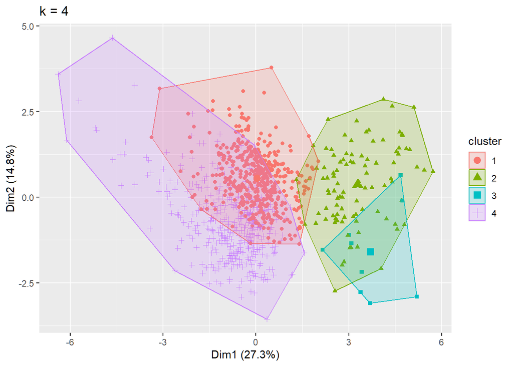

```r
p4
```

So as we can see, though the for k = 4, WSS for 4 clusters is : 2422.34254, 78.78635, 1016.91043, 2091.13619. Except for cluster#2, for other 3 clusters these WSS distances are huge, indicating that this is not an ideal situation. Also , Also, in the context of the within-cluster sum of squares (WCSS) and the between-cluster sum of squares (BCSS) ratio which is 37.3%, is not so great, although better than k=2. Since, we have to choose a reasonable number of clusters not compromising much on WSS, but at the same time having meaningful grouping, hence we choose k=4 as optimum number of clusters.

## Clustering for optimal k=4 for feature combination #2

Now since we have decided on optimal number of clusters as k=4, we are experimenting by changing our input as feature combination #2 (all features represented in terms of log-likelihood aligned for predicting target variable)

```r
k_pred <- kmeans(clust_df_pred1, centers = 4, nstart = 100, iter.max=100)
p_pred <- fviz_cluster(k_pred, geom = "point",  data = clust_df_pred1) + ggtitle("k = 4")
k_pred
```

```
## K-means clustering with 4 clusters of sizes 90, 558, 96, 251
##
## Cluster means:
##   predCountry predchannel_type predsubscribers predvideo_views preduploads
## 1   0.3289326        0.6388255       0.7873369       0.8006817   0.7884173
## 2   0.8825608        0.8356328       0.7990227       0.8134041   0.9070958
## 3   0.5924201        0.6621224       0.7862339       0.7881105   0.4901877
## 4   0.8571264        0.8299487       0.7920902       0.7891055   0.8909756
##   predvideo_views_for_the_last_30_days predsubscribers_for_last_30_days
## 1                           0.69877701                        0.7412356
## 2                           0.95690171                        0.9715501
## 3                           0.02160583                        0.5885341
## 4                           0.80773904                        0.5629940
##   predPopulation predAggregated_GDP predchannel_lifetime
## 1      0.3955094          0.5350815            0.7706243
```

[output cut: 114 more lines]

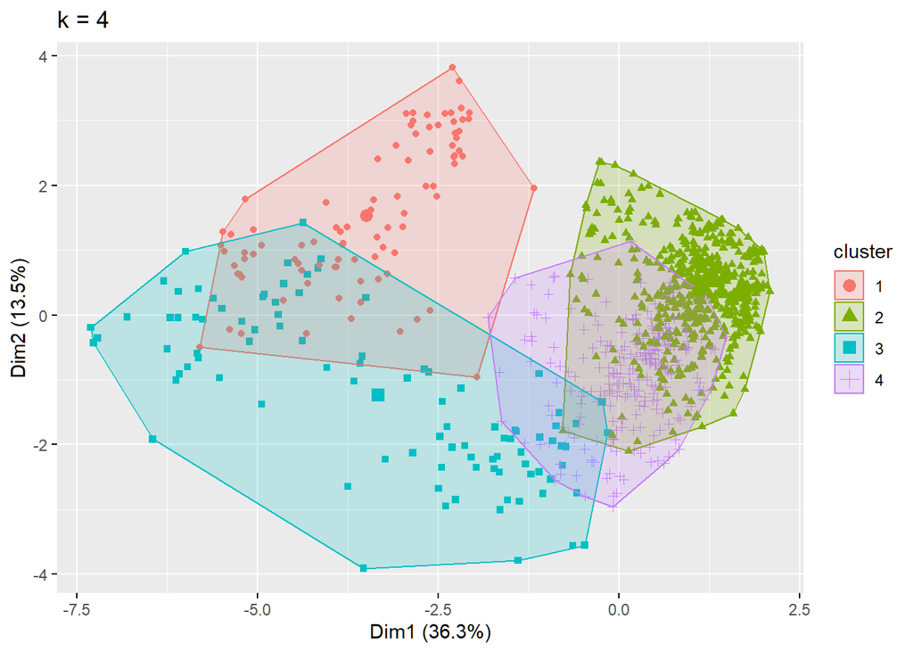

```r
p_pred
```

## Evaluation of clustering algorithm (Szepannek,2018)

We have selected Rand Index to evaluate the performance of the clustering algorithm and we are using ground truth to compare it with.Rand index= (TP+TN)/(TP+FP+FN+TN). The Rand index value for k=4 is 0.4855, which means that the four clusters have approx 49% overall similarity, which is quite reasonable for the given data set being an imbalanced one.We had 123 observations having NAs across six features, which might create erroneous groupings in during the clustering, impacting the accuracy and reliability of the clustering results.

```r
k_test<-kmeans(clust_df_pred1,centers=4, nstart = 100, iter.max=100)
k_test$size
```

```
## [1] 558 251  96  90
```

```r
cluster_similarity(k_test$cluster,training_prepared$earnings_level,similarity="rand")
```

```
## [1] 0.4855404
```

## Clustering for Mixed Data Types - k-prototypes algorithm (Szepannek,2018)

Since Kmeans is best suited with numerical data types only but in practical scenarios we are dealing with mix data types, so we have experimented with new algorithms for clustering mixed-type data based on Huang’s k-prototypes algorithm. The implementation followed here includes our data frame with “Country and”channel_type” categorical variables along with other numerical variables. Also since it is a mixed data type so no scaling is required, but factorization of categorical variables is required.

```r
#No scaling required because of categorical data

vars_to_drop1 <- c("predCountry", "predchannel_type", "predsubscribers", "predvideo_views", "preduploads", "predvideo_views_for_the_last_30_days", "predsubscribers_for_last_30_days", "predPopulation", "predAggregated_GDP", "predchannel_lifetime","earnings_level")

mix_clust_df <- training_prepared[, !(names(training_prepared) %in% vars_to_drop1)]
mix_clust_df$avg_earnings <- vtreat_prepared$avg_earnings
mix_clust_df$Country <- factor(training_prepared$Country)
mix_clust_df$channel_type <- factor(training_prepared$channel_type)

mix_clust_df$ID <- seq.int(nrow(mix_clust_df))
mix_clust_df1 <- subset(mix_clust_df, select = -ID)

str(mix_clust_df1)
```

```
## 'data.frame':    995 obs. of  11 variables:
##  $ Country                         : Factor w/ 50 levels "Afghanistan",..: 1 2 3 3 3 3 3 3 3 3 ...
##  $ channel_type                    : Factor w/ 15 levels "Animals","Autos",..: 7 12 5 9 7 3 12 9 9 7 ...
##  $ subscribers                     : num  16.8 16.5 16.8 17.4 16.6 ...
##  $ video_views                     : num  23.3 21.6 22.8 24 22.6 ...
##  $ uploads                         : num  0 5.07 4.42 6.48 8.5 ...
##  $ video_views_for_the_last_30_days: num  16.75 4.45 19.08 19.53 17.98 ...
##  $ subscribers_for_last_30_days    : num  2.48 11.44 12.21 12.9 12.21 ...
##  $ Population                      : num  17.5 19.2 17.6 17.6 17.6 ...
##  $ Aggregated_GDP                  : num  300 24620 5750 5750 5750 ...
##  $ channel_lifetime                : num  6174 6435 2473 3792 3333 ...
##  $ avg_earnings                    : num  1.00 2.13 4.94e+06 7.70e+06 1.65e+06 ...
```

# Using kproto method (Szepannek,2018)

```r
k_best <- 4
kpres<-kproto(x= mix_clust_df1,k=k_best)
```

```
## # NAs in variables:
##                          Country                     channel_type
##                                0                                0
##                      subscribers                      video_views
##                                0                                0
##                          uploads video_views_for_the_last_30_days
##                                0                                0
##     subscribers_for_last_30_days                       Population
##                                0                                0
##                   Aggregated_GDP                 channel_lifetime
##                                0                                0
##                     avg_earnings
##                                0
## 0 observation(s) with NAs.
##
## Estimated lambda: 7.120568e+12
##
## 0 observation(s) with NAs.
```

```r
kpres #output1
```

```
## Distance type: standard
##
## Numeric predictors: 9
## Categorical predictors: 2
## Lambda: 7.120568e+12
##
## Number of Clusters: 4
## Cluster sizes: 717 52 204 22
## Within cluster error: 7.810861e+15 1.405386e+15 2.878218e+15 3.943101e+15
##
## Cluster prototypes:
##         Country  channel_type subscribers video_views  uploads
## 1 United States Entertainment    16.72971    22.18262 5.875270
## 2 United States Entertainment    17.19688    23.70680 7.730227
## 3 United States         Music    16.95242    23.22156 7.280004
## 4         India Entertainment    17.51843    24.16973 8.930066
##   video_views_for_the_last_30_days subscribers_for_last_30_days Population
## 1                         15.65247                     10.89029   19.15366
## 2                         20.25776                     13.55493   19.33278
## 3                         19.22479                     12.54613   19.43443
## 4                         21.18023                     14.27352   19.28870
##   Aggregated_GDP channel_lifetime avg_earnings
## 1       15027.68         3940.606      1006642
## 2       14050.14         3045.615     16494231
## 3       14082.65         3928.706      6090014
## 4       13015.06         3751.136     41881818
```

```r
summary(kpres) #output2
```

```
## Country
##
## cluster Afghanistan Andorra Argentina Australia Bangladesh Barbados Brazil
##       1       0.001   0.001     0.008     0.010      0.001    0.000  0.067
##       2       0.000   0.000     0.058     0.000      0.000    0.000  0.038
##       3       0.000   0.000     0.020     0.010      0.000    0.005  0.054
##       4       0.000   0.000     0.000     0.000      0.000    0.000  0.045
##
## cluster Canada Chile China Colombia  Cuba Ecuador Egypt El Salvador Finland
##       1  0.017 0.004 0.001    0.004 0.001   0.003 0.003       0.001   0.001
##       2  0.019 0.000 0.000    0.019 0.000   0.000 0.000       0.000   0.000
##       3  0.010 0.000 0.000    0.034 0.000   0.000 0.000       0.000   0.000
##       4  0.000 0.000 0.000    0.000 0.000   0.000 0.000       0.000   0.000
##
## cluster France Germany India Indonesia  Iraq Italy Japan Jordan Kuwait Latvia
##       1  0.007   0.006 0.137     0.032 0.001 0.001 0.003  0.001  0.001  0.000
##       2  0.000   0.038 0.231     0.019 0.000 0.000 0.038  0.000  0.000  0.000
##       3  0.000   0.000 0.255     0.020 0.005 0.000 0.005  0.010  0.000  0.000
##       4  0.000   0.000 0.273     0.000 0.000 0.045 0.000  0.000  0.000  0.045
##
## cluster Malaysia Mexico Morocco Netherlands Pakistan  Peru Philippines Russia
##       1    0.001  0.043   0.001       0.004    0.004 0.001       0.010  0.014
##       2    0.000  0.000   0.000       0.000    0.019 0.000       0.019  0.058
##       3    0.000  0.010   0.000       0.000    0.000 0.000       0.020  0.015
##       4    0.000  0.000   0.000       0.000    0.091 0.000       0.000  0.000
##
## cluster Samoa Saudi Arabia Singapore South Korea Spain Sweden Switzerland
##       1 0.001        0.013     0.004       0.015 0.028  0.004       0.001
##       2 0.000        0.000     0.000       0.058 0.000  0.019       0.000
##       3 0.000        0.000     0.000       0.010 0.010  0.000       0.000
##       4 0.000        0.000     0.000       0.045 0.000  0.000       0.000
##
## cluster Thailand Turkey Ukraine United Arab Emirates United Kingdom
##       1    0.018  0.003   0.010                0.004          0.047
##       2    0.000  0.000   0.000                0.000          0.019
##       3    0.025  0.005   0.005                0.015          0.039
##       4    0.000  0.045   0.000                0.045          0.000
##
## cluster United States Unknown Venezuela Vietnam
##       1         0.305   0.146     0.001   0.003
```

[output cut: 77 more lines]

```
##   Min. 1st Qu. Median     Mean 3rd Qu. Max.
## 1  484 2773.00 3871.0 3940.606 5116.00 6698
## 2  855 1562.75 2735.0 3045.615 3965.75 6348
## 3  800 2829.25 3813.5 3928.706 5165.00 6698
## 4  756 1528.00 3667.5 3751.136 5887.25 6526
##
## -----------------------------------------------------------------
## avg_earnings
##          Min.  1st Qu.   Median     Mean  3rd Qu.     Max.
## 1 2.50000e-02    26600   691050  1006642  1646150  4037800
## 2 1.09500e+07 12775000 15525000 16494231 19262500 27550000
## 3 2.86725e+06  4303425  5579100  6090014  7769488 11400000
## 4 2.93000e+07 32337500 39025000 41881818 45750000 86800000
##
## -----------------------------------------------------------------
```

```r
#library(wesanderson)
#par(mfrow=c(2,2))
#clprofiles(kpres,training_prepared,col=wes_palette("Royal1",k_best,type="continuous"))
```

Here lambda > 0 is a real valued parameter that controls the trade off between Euclidean distance for numeric variables and simple matching distance for factor variables for cluster assignment. In our case for k=4, lambda = 7.120568e+12 which implies that the categorical features are playing a more significant role in determining the clusters.Consequently, the algorithm tends to form clusters primarily based on the patterns in the categorical data. With such a high lambda value, the algorithm downplays the importance of numerical attributes. This makes sense to say that the categorical attributes are more meaningful (Country and channel_type) or if the numerical attributes are less significant in distinguishing between clusters.

# Comparison of Kproto, Kmeans and Kmodes algorithms based on Rand Index (Szepannek,2018)

```r
kpres<-kproto(x= mix_clust_df1,k=4) ## kproto using mixed datatypes
```

```
## # NAs in variables:
##                          Country                     channel_type
##                                0                                0
##                      subscribers                      video_views
##                                0                                0
##                          uploads video_views_for_the_last_30_days
##                                0                                0
##     subscribers_for_last_30_days                       Population
##                                0                                0
##                   Aggregated_GDP                 channel_lifetime
##                                0                                0
##                     avg_earnings
##                                0
## 0 observation(s) with NAs.
##
## Estimated lambda: 7.120568e+12
##
## 0 observation(s) with NAs.
```

```r
kmres<-kmeans(mix_clust_df1[,3:10],4) # kmeans using numerics only
kmores<-kmodes(mix_clust_df1[,1:2],4) # kmodes using factors only


cluster_similarity(kpres$cluster,training_prepared$earnings_level,similarity="rand")
```

```
## [1] 0.4725337
```

```r
cluster_similarity(kmres$cluster,training_prepared$earnings_level,similarity="rand")
```

```
## [1] 0.4766913
```

```r
cluster_similarity(kmores$cluster,training_prepared$earnings_level,similarity="rand")
```

```
## [1] 0.450138
```

# References

Szepannek, G.(2018).clustMixType:User-FriendlyClustering of Mixed-Type Data in R.The R Journal Vol. 10/2, December 2018 ISSN 2073-4859 Boehmke, B.(2018). UC Business Analytics R Programming Guide. https://uc-r.github.io/kmeans_clustering

Yu, Z.(2023, Sep 02). Tutorial: an interactive R shiny app visulaling K-means clustering of the Iris dataset. https://rpubs.com/ZixuanYu/iris_kmeans_clustering

Deshpande, R. (2020, May 21). R Shiny App — Creating an App on R shiny and sharing with Shinyapps.io https://medium.com/codex/r-shiny-app-creating-an-app-on-r-shiny-and-sharing-with-shinyapps-io-a6f519c02f48 https://ruchideshpande.shinyapps.io/csapp/

Jette, P. (2019, Jan 02). Entropy, Information Gain, and Data Exploration in R. https://rstudio-pubs-static.s3.amazonaws.com/455435_30729e265f7a4d049400d03a18e218db.html

Brownlee, J. (2020, Dec 10). Information Gain and Mutual Information for Machine Learning. https://machinelearningmastery.com/information-gain-and-mutual-information/

Week 10 lab, and lecture slides from week 4 to week 11 of CITS 4009 for code, and concept.

https://rstudio.github.io/cheatsheets/shiny.pdf for various shiny app elements especially concerning the UI

https://www.kaggle.com/datasets/nelgiriyewithana/global-youtube-statistics-2023 for better understanding of the data set and the features within them.

https://chat.openai.com/ Chat GPTs was used extensively for various purposes. The concept behind code chunks obtained from the lecture was understood by having GPT explain it line for line, meaning and concept of various models and evaluation metrics were made clearer, complex function that were very difficult to troubleshoot were fed in to GPT, but the answers were not always clear but it still helped.

https://cran.r-project.org/manuals.html

https://www.rdocumentation.org/

https://www.r-project.org/other-docs.html